# MSDS-6372-Project2

Holmes, Karki, Webb

11/12/2022

### Libraries

```
## [1] "aplore3"
## [1] "tidyverse"
## [1] "corrplot"
## [1] "car"
## [1] "caTools"
## [1] "ROCR"
## [1] "caret"
## [1] "naniar"
## [1] "GGally"
## [1] "rgl"
## [1] "MVN"
## [1] "gplots"
## [1] "MASS"
## [1] "pROC"
## [1] "klaR"
## [1] "class"
```

### Outline

We are using the Glow Bonemed dataset from the aplore3 package. This dataset covers the classification problem of whether or not a woman with osteoporosis will have a bone fracture within the first five years of joining the study. The dataset has 500 records with 20 variables. Of those variables, 9 are numeric and 10 are categorical.

We will be applying three diffent classification methods and comparing their performance across six metrics.

Methods

- Logistic Regression
- LDA/QDA
- KNN

Metrics

- Sensitivity
- Specificity
- Prevalence
- Positive Predictive Value
- Negative Predictive Value
- Area Under ROC curve

### EDA

The overall ratio is 3 to 1 in favor of No fracture. This makes the Yes outcome a fairly rare event for this data set.

| fracture | cnt | perc |
| --- | --- | --- |
| No | 375 | 0.75 |
| Yes | 125 | 0.25 |

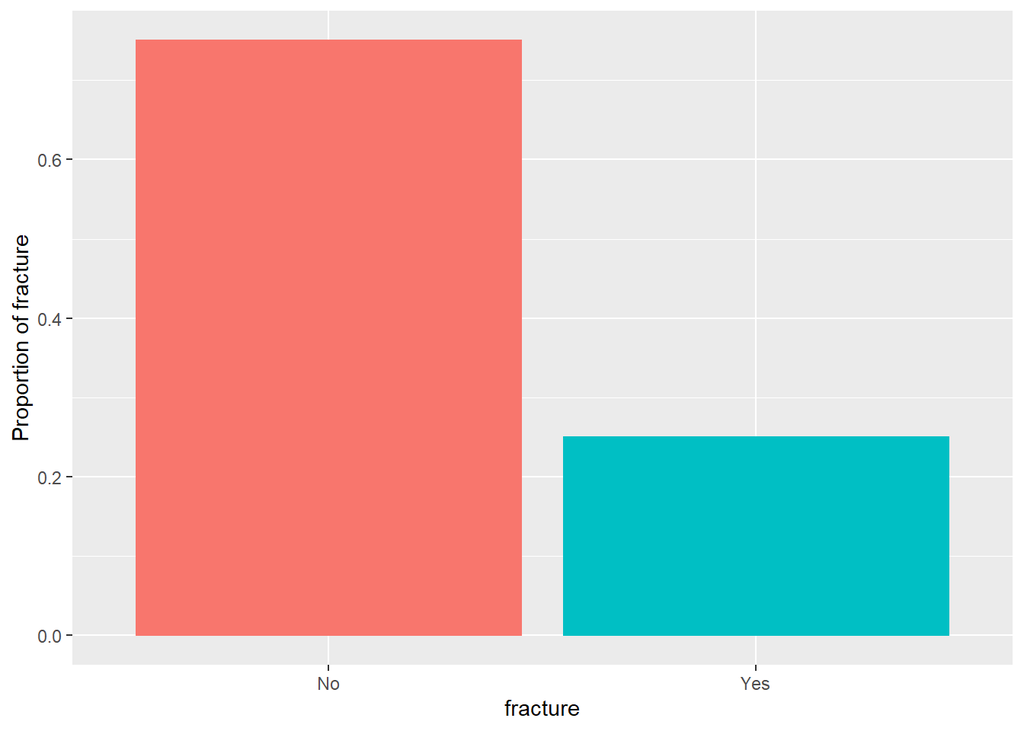

**Missing Data**

No columns have missing Data.

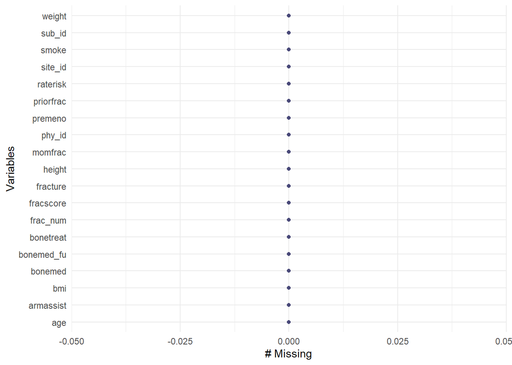

# # **Categorical Variables**

In this section we are looking for two things.

1. Significantly different ratio between the fracture classification variable when grouping by the independent variable
2. Higher fracture rate in the Yes group in particular factor of the grouped by variable.

In the case of Prior Fracture we see a significantly different ratio between the Yes and No Fracture group. There is an 80/20 split for the No group and a 58/42 split for the Yes group. This is a possible indication of an important variable. The table shows two times higher chance of having a fracture if the woman had a prior fracture.

| fracture | priorfrac | cnt | perc |
| --- | --- | --- | --- |
| No | No | 301 | 0.8027 |
| No | Yes | 74 | 0.1973 |
| Yes | No | 73 | 0.5840 |
| Yes | Yes | 52 | 0.4160 |

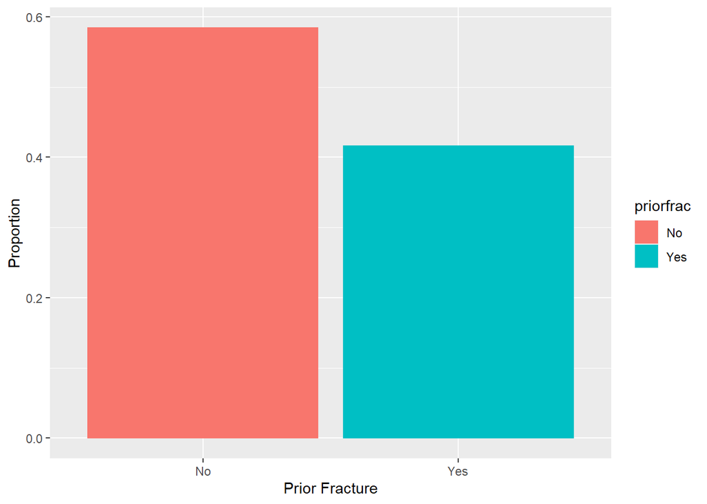

| fracture | momfrac | cnt | perc |
| --- | --- | --- | --- |
| No | No | 334 | 0.8907 |
| No | Yes | 41 | 0.1093 |
| Yes | No | 101 | 0.8080 |
| Yes | Yes | 24 | 0.1920 |

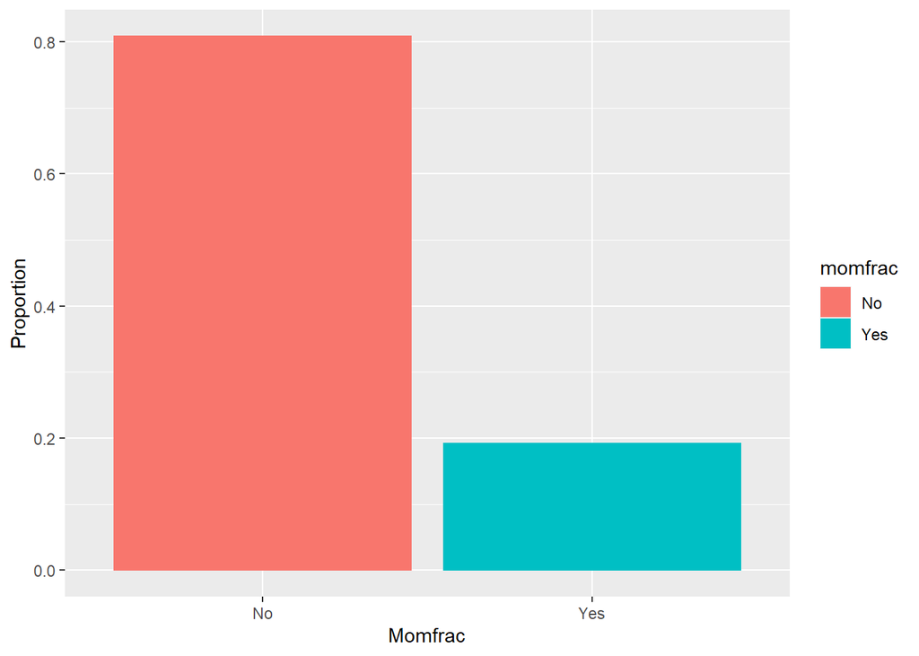

Another promising variable is Armassit. This variable tracks if Arms are needed to stand from a chair. This is the first variable that shows a higher chance of fracture for the predictor variable Yes than the No. It also shows a significant increase in ratio compared to the No fracture group.

| fracture | armassist | cnt | perc |
| --- | --- | --- | --- |
| No | No | 250 | 0.6667 |
| No | Yes | 125 | 0.3333 |
| Yes | Yes | 63 | 0.5040 |
| Yes | No | 62 | 0.4960 |

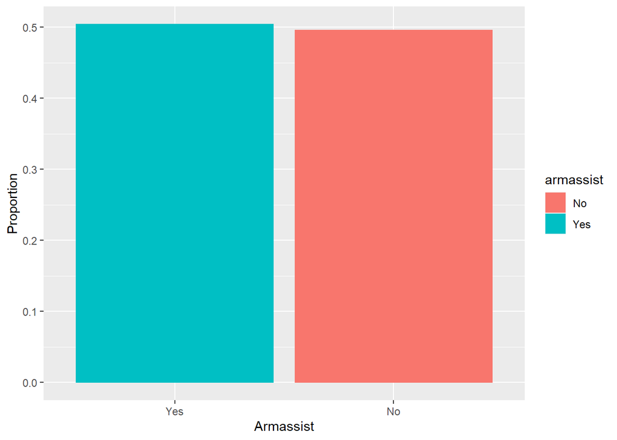

| fracture | smoke | cnt | perc |
| --- | --- | --- | --- |
| No | No | 347 | 0.9253 |
| No | Yes | 28 | 0.0747 |
| Yes | No | 118 | 0.9440 |
| Yes | Yes | 7 | 0.0560 |

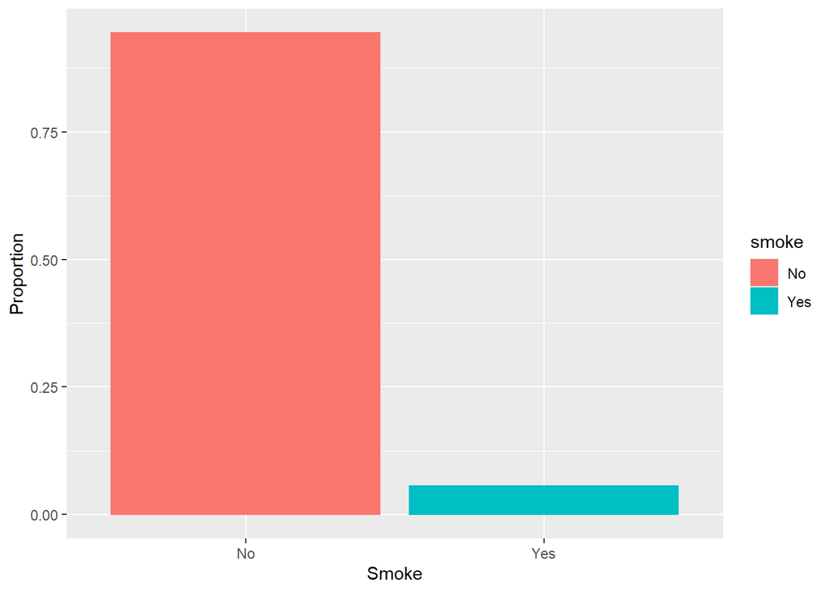

The remaining variables show some increase in fractures from the same factor level when comparing No vs. Yes fracture status. There are no variables that stand out as being significantly important to predicting fractures.

| fracture | premeno | cnt | perc |
| --- | --- | --- | --- |
| No | No | 303 | 0.808 |
| No | Yes | 72 | 0.192 |
| Yes | No | 100 | 0.800 |
| Yes | Yes | 25 | 0.200 |

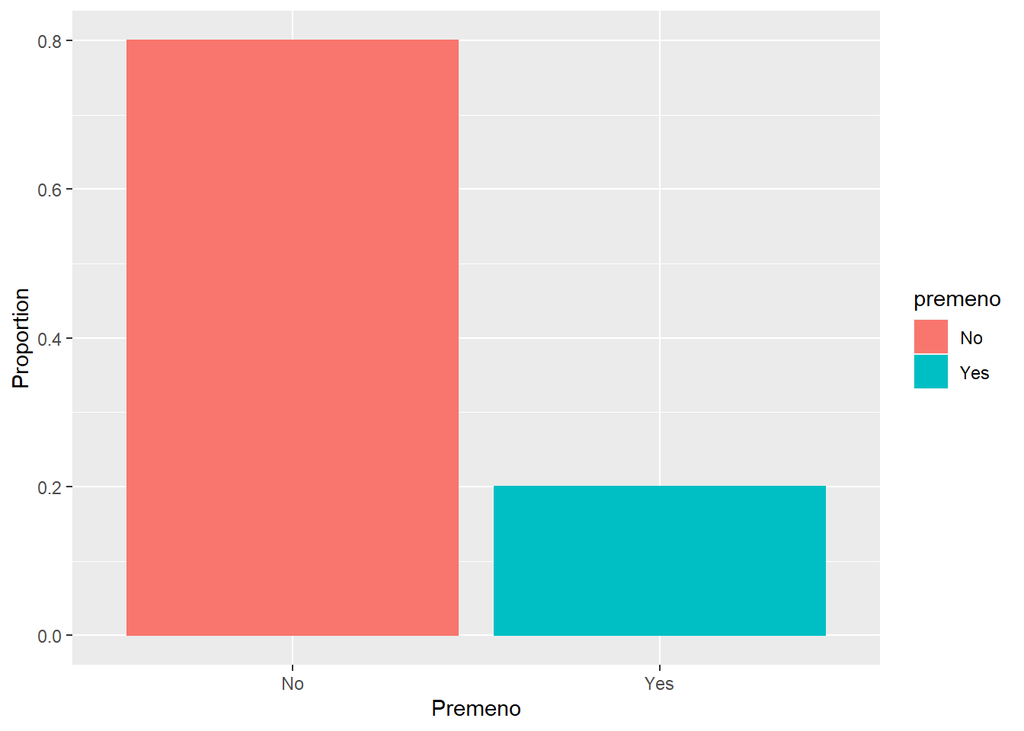

| fracture | raterisk | cnt | perc |
| --- | --- | --- | --- |
| No | Less | 139 | 0.3707 |
| No | Same | 138 | 0.3680 |
| No | Greater | 98 | 0.2613 |
| Yes | Greater | 49 | 0.3920 |
| Yes | Same | 48 | 0.3840 |
| Yes | Less | 28 | 0.2240 |

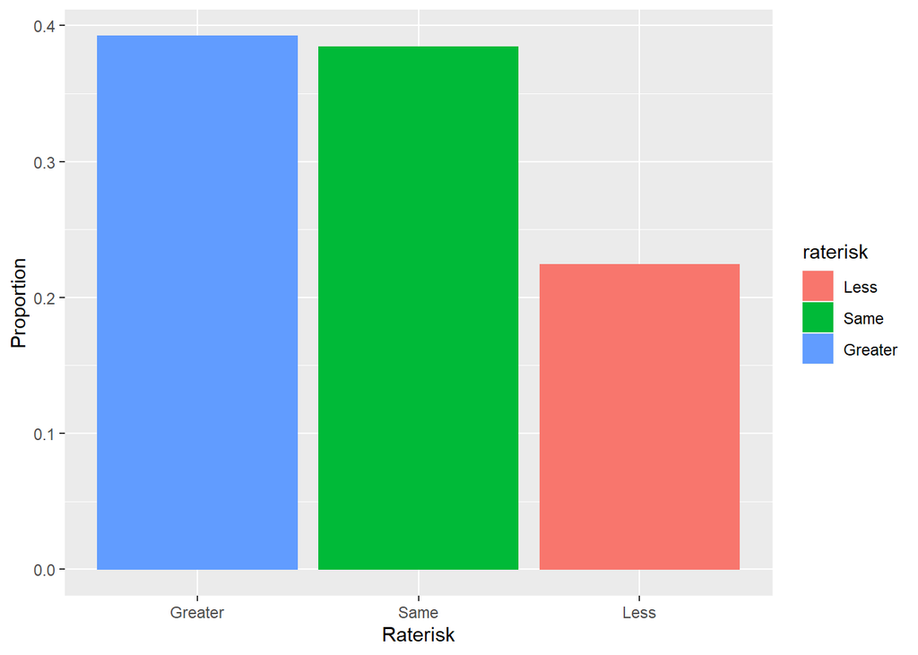

| fracture | bonemed | cnt | perc |
| --- | --- | --- | --- |
| No | No | 292 | 0.7787 |
| No | Yes | 83 | 0.2213 |
| Yes | No | 79 | 0.6320 |
| Yes | Yes | 46 | 0.3680 |

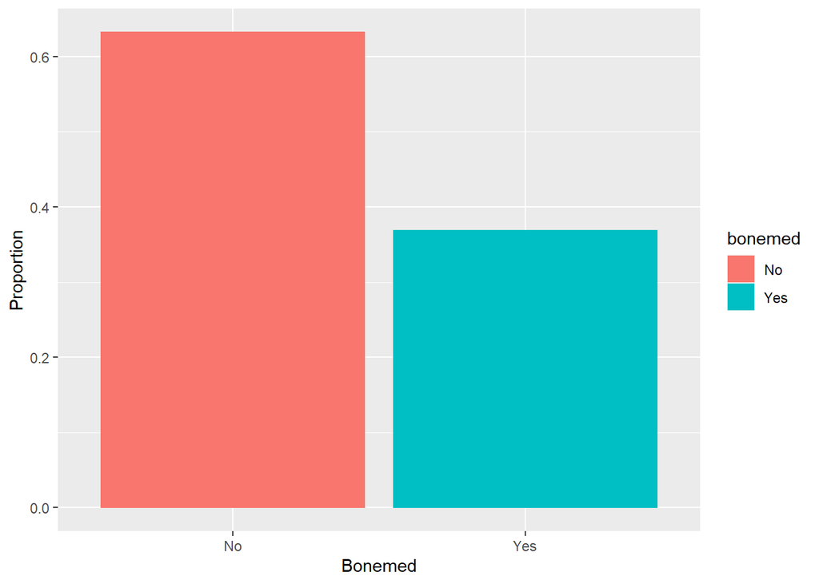

| fracture | bonemed_fu | cnt | perc |
| --- | --- | --- | --- |
| No | No | 289 | 0.7707 |
| No | Yes | 86 | 0.2293 |
| Yes | No | 72 | 0.5760 |
| Yes | Yes | 53 | 0.4240 |

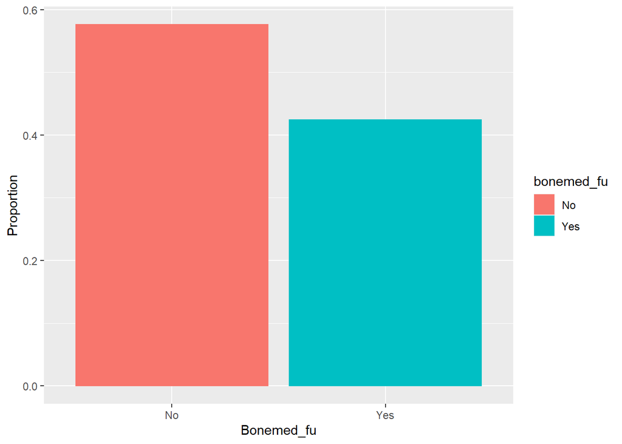

| fracture | bonetreat | cnt | perc |
| --- | --- | --- | --- |
| No | No | 297 | 0.792 |
| No | Yes | 78 | 0.208 |
| Yes | No | 85 | 0.680 |
| Yes | Yes | 40 | 0.320 |

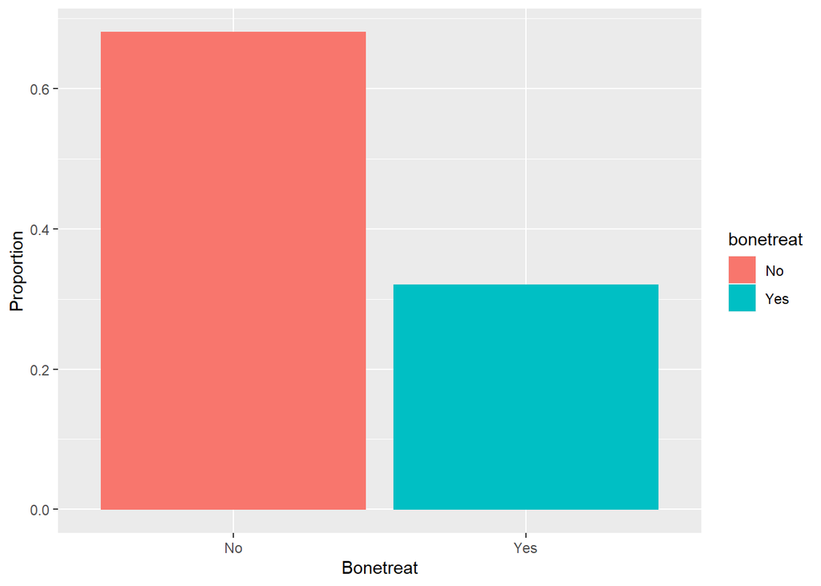

**Numeric Variables**

Similar to the categorical variables, we see some positive signs of variables being important in predicting bone fractures, but none show overwhelming evidence of significance in their Loess plots.

Age, Height, and Fracscore show the most evidence of trend.

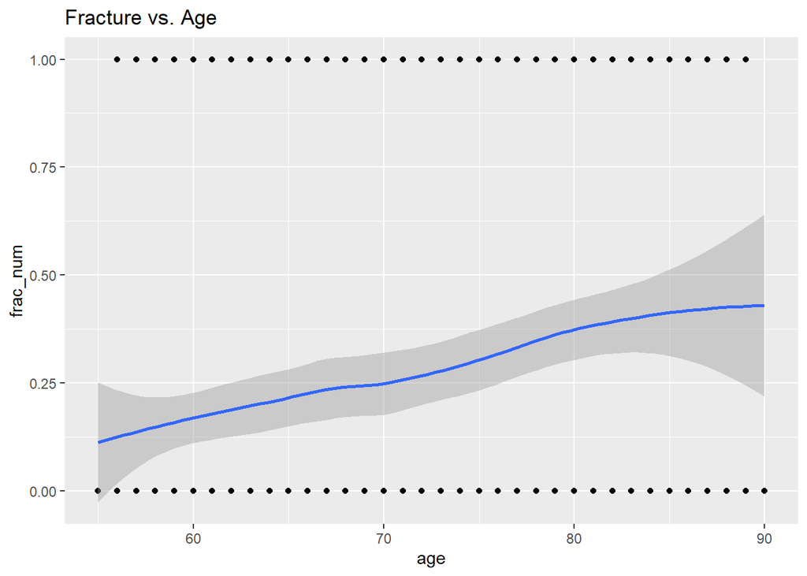

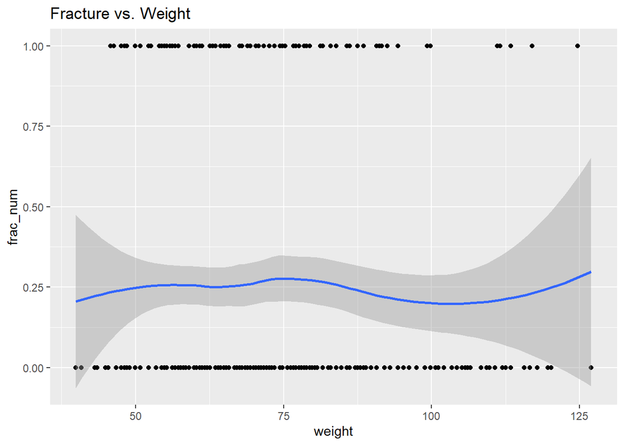

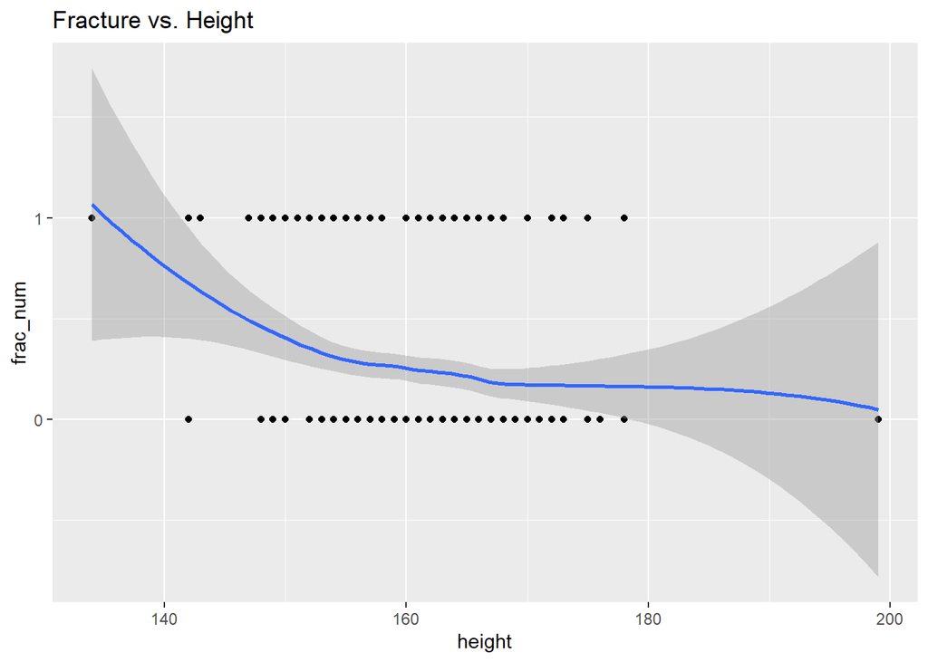

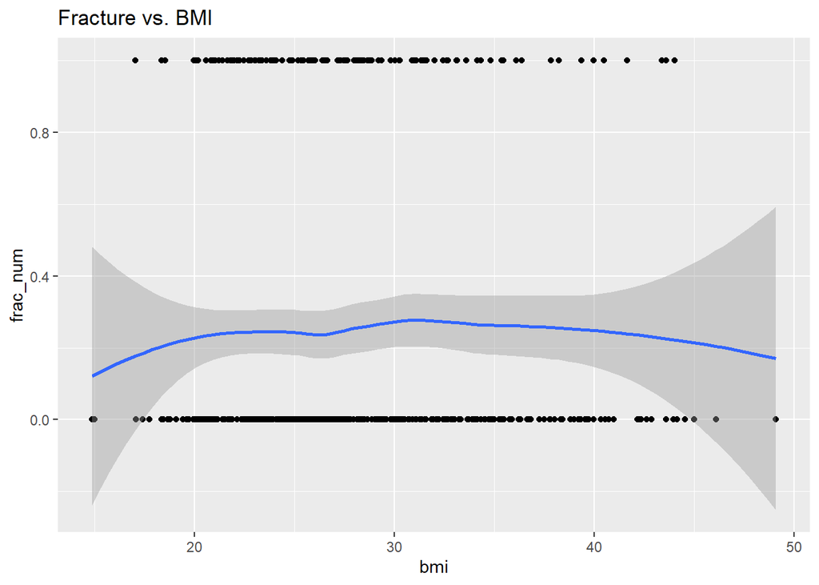

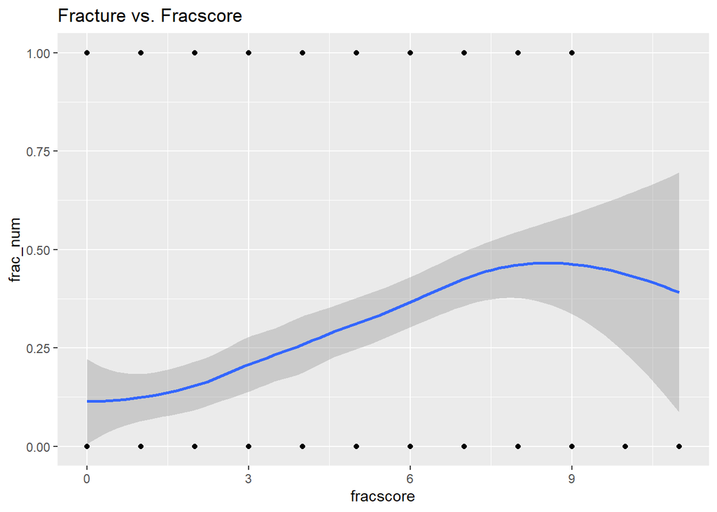

# We also looked at scatter plots in both 2 and 3 dimensions and found no evidence of clustering. The Fracscore vs Height plot below is indicative of what we saw in both 2 and 3 dimensions for all numeric pairings.

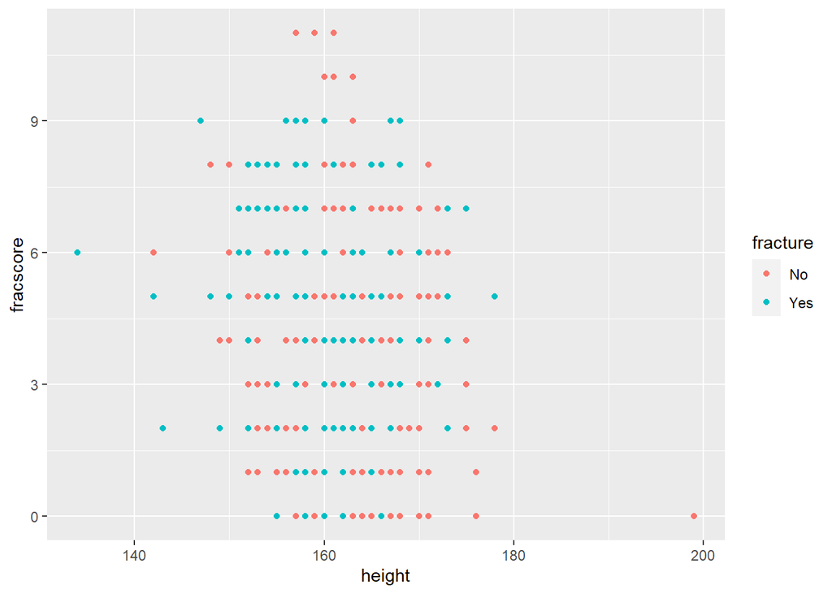

**Correlation**

When looking at the numeric variable correlation factors, we see strong multicollinearity between Age/Fracscore, BMI/Weight, and Phy_ID/Site_ID. This is corroborated by high VIF scores for these variables.

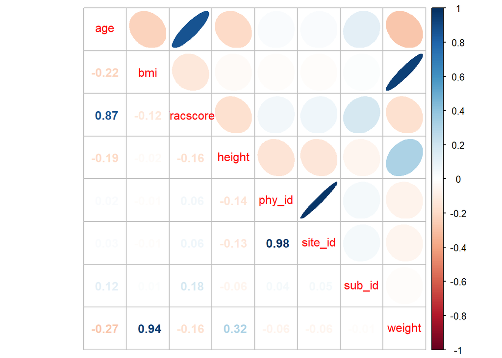

```
##                  GVIF Df GVIF^(1/(2*Df))
## sub_id       1.100237  1        1.048922
## site_id     20.792887  1        4.559922
## phy_id      20.804483  1        4.561193
## priorfrac    2.651976  1        1.628489
## age         21.622239  1        4.649972
## weight     162.503141  1       12.747672
## height      20.315556  1        4.507278
## bmi        148.354839  1       12.180100
## premeno      1.083204  1        1.040771
## momfrac      1.875725  1        1.369571
## armassist    7.299268  1        2.701716
## smoke        1.526654  1        1.235578
## raterisk     1.295022  2        1.066766
## fracscore   40.730029  1        6.382008
## bonemed      9.344408  1        3.056862
## bonemed_fu   5.441371  1        2.332675
## bonetreat   14.028637  1        3.745482
```

### Train/Test Split

We used an 80/20 split with a seed of 123 for all methods.

### Objective 1

Display the ability to perform EDA and build a logistic regression model for interpretation purposes.

**Simple Logistic Regression**

Removing BMI, Age, and Site ID due to multicollinearity.

```r
# Logistic Model
log_model <- glm(fracture ~ ., data = train_sub, family = "binomial")
coef(summary(log_model))
```

```
##                      Estimate  Std. Error    z value    Pr(>|z|)
## (Intercept)      2.7808871687 3.507199009  0.7929083 0.427831257
## phy_id           0.0005443462 0.001076349  0.5057340 0.613043386
## priorfracYes     0.5389699233 0.304505943  1.7699816 0.076730203
## weight           0.0090799509 0.009455170  0.9603160 0.336896220
## height          -0.0372711426 0.021889154 -1.7027219 0.088620126
## premenoYes       0.2851930284 0.318602766  0.8951367 0.370714018
## momfracYes       0.6241579647 0.363012919  1.7193822 0.085544795
## armassistYes    -0.1306623013 0.380684054 -0.3432303 0.731425213
## rateriskSame     0.1734424663 0.314806613  0.5509492 0.581668467
## rateriskGreater  0.3213324340 0.348691430  0.9215381 0.356769565
## fracscore        0.1780079937 0.082934457  2.1463695 0.031843507
## bonemedYes       0.9946690073 0.744222867  1.3365204 0.181379253
## bonemed_fuYes    1.5432193970 0.573266834  2.6919740 0.007103049
## bonetreatYes    -2.0995224048 0.947584344 -2.2156575 0.026714964
```

*Variable Selection*

Forward

```
##
## Call:
## glm(formula = fracture ~ phy_id + priorfrac + weight + height +
##     premeno + momfrac + armassist + raterisk + fracscore + bonemed +
##     bonemed_fu + bonetreat, family = "binomial", data = train_sub)
##
## Deviance Residuals:
##     Min       1Q   Median       3Q      Max
## -1.7458  -0.7519  -0.5372  -0.2659   2.2617
##
## Coefficients:
##                   Estimate Std. Error z value Pr(>|z|)
## (Intercept)      2.7808872  3.5071990   0.793   0.4278
## phy_id           0.0005443  0.0010763   0.506   0.6130
## priorfracYes     0.5389699  0.3045059   1.770   0.0767 .
## weight           0.0090800  0.0094552   0.960   0.3369
## height          -0.0372711  0.0218892  -1.703   0.0886 .
## premenoYes       0.2851930  0.3186028   0.895   0.3707
## momfracYes       0.6241580  0.3630129   1.719   0.0855 .
## armassistYes    -0.1306623  0.3806841  -0.343   0.7314
## rateriskSame     0.1734425  0.3148066   0.551   0.5817
## rateriskGreater  0.3213324  0.3486914   0.922   0.3568
## fracscore        0.1780080  0.0829345   2.146   0.0318 *
## bonemedYes       0.9946690  0.7442229   1.337   0.1814
## bonemed_fuYes    1.5432194  0.5732668   2.692   0.0071 **
## bonetreatYes    -2.0995224  0.9475843  -2.216   0.0267 *
## ---
## Signif. codes:  0 '***' 0.001 '**' 0.01 '*' 0.05 '.' 0.1 ' ' 1
##
## (Dispersion parameter for binomial family taken to be 1)
##
##     Null deviance: 455.51  on 405  degrees of freedom
## Residual deviance: 403.34  on 392  degrees of freedom
## AIC: 431.34
##
## Number of Fisher Scoring iterations: 4
```

AIC

```
## [1] 431.3438
```

BIC

```
## [1] 487.4327
```

Backward

```
##
## Call:
## glm(formula = fracture ~ priorfrac + height + momfrac + fracscore +
##     bonemed_fu + bonetreat, family = "binomial", data = train_sub)
##
## Deviance Residuals:
##     Min       1Q   Median       3Q      Max
## -1.6325  -0.7403  -0.5585  -0.2808   2.2071
##
## Coefficients:
##               Estimate Std. Error z value Pr(>|z|)
## (Intercept)    3.11621    3.25144   0.958  0.33786
## priorfracYes   0.64333    0.28816   2.233  0.02558 *
## height        -0.03289    0.02001  -1.644  0.10017
## momfracYes     0.62484    0.34863   1.792  0.07309 .
## fracscore      0.15092    0.05635   2.678  0.00740 **
## bonemed_fuYes  1.55742    0.55809   2.791  0.00526 **
## bonetreatYes  -1.16184    0.58578  -1.983  0.04732 *
## ---
## Signif. codes:  0 '***' 0.001 '**' 0.01 '*' 0.05 '.' 0.1 ' ' 1
##
## (Dispersion parameter for binomial family taken to be 1)
##
##     Null deviance: 455.51  on 405  degrees of freedom
## Residual deviance: 407.95  on 399  degrees of freedom
## AIC: 421.95
##
## Number of Fisher Scoring iterations: 4
```

AIC

```
## [1] 421.951
```

BIC

```
## [1] 449.9955
```

Both

```
##
## Call:
## glm(formula = fracture ~ priorfrac + height + momfrac + fracscore +
##     bonemed_fu + bonetreat, family = "binomial", data = train_sub)
##
## Deviance Residuals:
##     Min       1Q   Median       3Q      Max
## -1.6325  -0.7403  -0.5585  -0.2808   2.2071
##
## Coefficients:
##               Estimate Std. Error z value Pr(>|z|)
## (Intercept)    3.11621    3.25144   0.958  0.33786
## priorfracYes   0.64333    0.28816   2.233  0.02558 *
## height        -0.03289    0.02001  -1.644  0.10017
## momfracYes     0.62484    0.34863   1.792  0.07309 .
## fracscore      0.15092    0.05635   2.678  0.00740 **
## bonemed_fuYes  1.55742    0.55809   2.791  0.00526 **
## bonetreatYes  -1.16184    0.58578  -1.983  0.04732 *
## ---
## Signif. codes:  0 '***' 0.001 '**' 0.01 '*' 0.05 '.' 0.1 ' ' 1
##
## (Dispersion parameter for binomial family taken to be 1)
##
##     Null deviance: 455.51  on 405  degrees of freedom
## Residual deviance: 407.95  on 399  degrees of freedom
## AIC: 421.95
##
## Number of Fisher Scoring iterations: 4
```

AIC

```
## [1] 421.951
```

BIC

```
## [1] 449.9955
```

Four variables were found to be significant in the final model.

The odds of having a fracture are 1.90 times higher for women of have had a prior fracture (priorfrac) than those that have not (p-value = 0.026). The 95% confidence interval for this increase is (1.079, 3.348)

The odds of having a fracture are 4.75 times higher for women who receive bone medication at follow-up (bonemed_fu) than for those who did not (p-value = 0.005). The 95% confidence interval for this increase is (1.609, 14.939)

The odds of having a fracture are .31 times lower for women who receive bone medication at both enrollment (bonetreat) and follow-up (p-value = 0.047). The 95% confidence interval for this decrease is (0.094, 0.972)

For a one unit increase in fracscore the odds of fracture increase by a multiplicative factor of 1.16 (p-value = 0.007) with a 95% confidence interval of (1.041, 1.300).

Coefficients

```
##   (Intercept)  priorfracYes        height    momfracYes     fracscore
##    22.5607384     1.9028006     0.9676421     1.8679401     1.1628980
## bonemed_fuYes  bonetreatYes
##     4.7465628     0.3129087
```

Confidence Intervals

```
##                    2.5 %       97.5 %
## (Intercept)   0.04087829 1.443298e+04
## priorfracYes  1.07897969 3.347662e+00
## height        0.92980964 1.005838e+00
## momfracYes    0.93083956 3.674682e+00
## fracscore     1.04158574 1.299823e+00
## bonemed_fuYes 1.60898637 1.493869e+01
## bonetreatYes  0.09445368 9.724499e-01
```

Final Model

```r
log_model <-
  glm(fracture ~ priorfrac + height + momfrac + fracscore + bonemed_fu + bonetreat,
  data = train_sub, family = "binomial")
summary(log_model)
```

```
##
## Call:
## glm(formula = fracture ~ priorfrac + height + momfrac + fracscore +
##     bonemed_fu + bonetreat, family = "binomial", data = train_sub)
##
## Deviance Residuals:
##     Min       1Q   Median       3Q      Max
## -1.6325  -0.7403  -0.5585  -0.2808   2.2071
##
## Coefficients:
##               Estimate Std. Error z value Pr(>|z|)
## (Intercept)    3.11621    3.25144   0.958  0.33786
## priorfracYes   0.64333    0.28816   2.233  0.02558 *
## height        -0.03289    0.02001  -1.644  0.10017
## momfracYes     0.62484    0.34863   1.792  0.07309 .
## fracscore      0.15092    0.05635   2.678  0.00740 **
## bonemed_fuYes  1.55742    0.55809   2.791  0.00526 **
## bonetreatYes  -1.16184    0.58578  -1.983  0.04732 *
## ---
## Signif. codes:  0 '***' 0.001 '**' 0.01 '*' 0.05 '.' 0.1 ' ' 1
##
## (Dispersion parameter for binomial family taken to be 1)
##
##     Null deviance: 455.51  on 405  degrees of freedom
## Residual deviance: 407.95  on 399  degrees of freedom
## AIC: 421.95
##
## Number of Fisher Scoring iterations: 4
```

In the case of this data set, the model is much more likely to predict No than Yes. This makes sense given the data we found in the EDA portion of our research. There were no variables with obvious correlation to our positive predicted class.

```
## Confusion Matrix and Statistics
##
##           Reference
## Prediction No Yes
##        No  66  17
##        Yes  4   7
##
##                Accuracy : 0.7766
##                  95% CI : (0.679, 0.8561)
##     No Information Rate : 0.7447
##     P-Value [Acc > NIR] : 0.281534
##
##                   Kappa : 0.2853
##
##  Mcnemar's Test P-Value : 0.008829
##
##             Sensitivity : 0.9429
##             Specificity : 0.2917
##          Pos Pred Value : 0.7952
##          Neg Pred Value : 0.6364
##              Prevalence : 0.7447
##          Detection Rate : 0.7021
##    Detection Prevalence : 0.8830
##       Balanced Accuracy : 0.6173
##
##        'Positive' Class : No
##
```

For this particular study, there is merit to reducing the threshold for positive prediction below 50%. A case can be made that Specificity is more important than Sensitivity in the case of predicting fractures. It might be more important for the model to capture as many of the Fracture cases at the expense of incorrectly predicting fractures for some women.

In addition to the practical reason for reducing the threshold, our positive classification only makes up 25% of the overall sample. For both of these reasons, we have reduced our threshold in the below model. We found that a threshold that mirrored the sample distribution produced the most balanced results between Sensitivity and Specificity.

```
## Confusion Matrix and Statistics
##
##           Reference
## Prediction No Yes
##        No  51   9
##        Yes 19  15
##
##                Accuracy : 0.7021
##                  95% CI : (0.599, 0.7921)
##     No Information Rate : 0.7447
##     P-Value [Acc > NIR] : 0.85604
##
##                   Kappa : 0.311
##
##  Mcnemar's Test P-Value : 0.08897
##
##             Sensitivity : 0.7286
##             Specificity : 0.6250
##          Pos Pred Value : 0.8500
##          Neg Pred Value : 0.4412
##              Prevalence : 0.7447
##          Detection Rate : 0.5426
##    Detection Prevalence : 0.6383
##       Balanced Accuracy : 0.6768
##
##        'Positive' Class : No
##
```

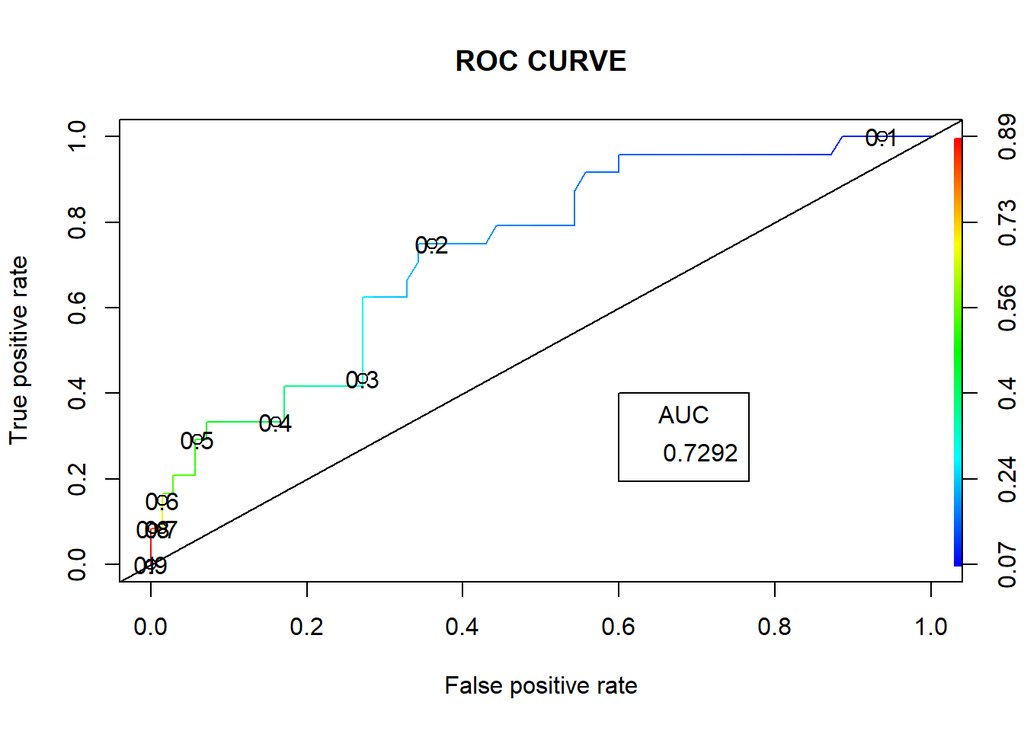

# **Results**

Our final model produced the following metrics.

- Sensitivity = .729
- Specificity = .625
- Prevalence = .745
- Positive Predictive Value = .850
- Negative Predictive Value = .441
- Area Under ROC curve = .729

### Objective 2

**KNN**

```
##
##  No Yes
## 375 125
```

Number of observations

```
## [1] 396
```

Square root of observations produces a decent k value.

```
## [1] 19.89975
```

k = 20 Accuracy

```
## [1] 75.96154
```

k = 21 Accuracy

```
## [1] 75
```

Here, we check predictions against actual values in tabular form. Zero maps to No and one maps to Yes for fractures.

```
##       test.bone_labels
## knn.20  0  1
##      0 78 24
##      1  1  1
```

```
##       test.bone_labels
## knn.21  0  1
##      0 78 25
##      1  1  0
```

Here, we look at not fractured as positive class

```
## Confusion Matrix and Statistics
##
##           Reference
## Prediction  0  1
##          0 78 25
##          1  1  0
##
##                Accuracy : 0.75
##                  95% CI : (0.6555, 0.8297)
##     No Information Rate : 0.7596
##     P-Value [Acc > NIR] : 0.6411
##
##                   Kappa : -0.0188
##
##  Mcnemar's Test P-Value : 6.462e-06
##
##             Sensitivity : 0.9873
##             Specificity : 0.0000
##          Pos Pred Value : 0.7573
##          Neg Pred Value : 0.0000
##              Prevalence : 0.7596
##          Detection Rate : 0.7500
##    Detection Prevalence : 0.9904
##       Balanced Accuracy : 0.4937
##
##        'Positive' Class : 0
##
```

Below is the elbow plot of Accuracy for various k values.

```
## 1 = 71.15385
## 2 = 75
## 3 = 73.07692
## 4 = 74.03846
## 5 = 75.96154
## 6 = 73.07692
## 7 = 75
## 8 = 75
## 9 = 73.07692
## 10 = 73.07692
## 11 = 75
## 12 = 75
## 13 = 74.03846
## 14 = 75
## 15 = 75
## 16 = 73.07692
## 17 = 74.03846
## 18 = 74.03846
## 19 = 75.96154
## 20 = 75.96154
## 21 = 75
## 22 = 75
## 23 = 75
## 24 = 75
## 25 = 75
```

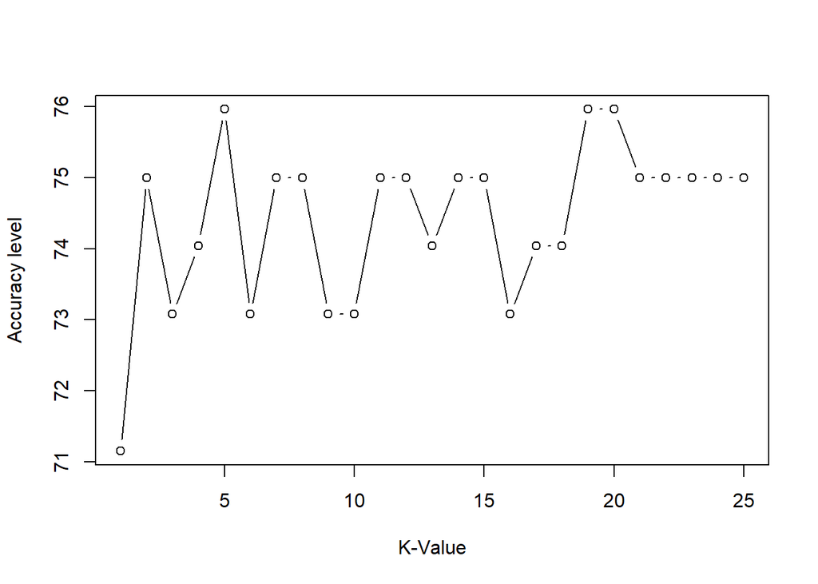

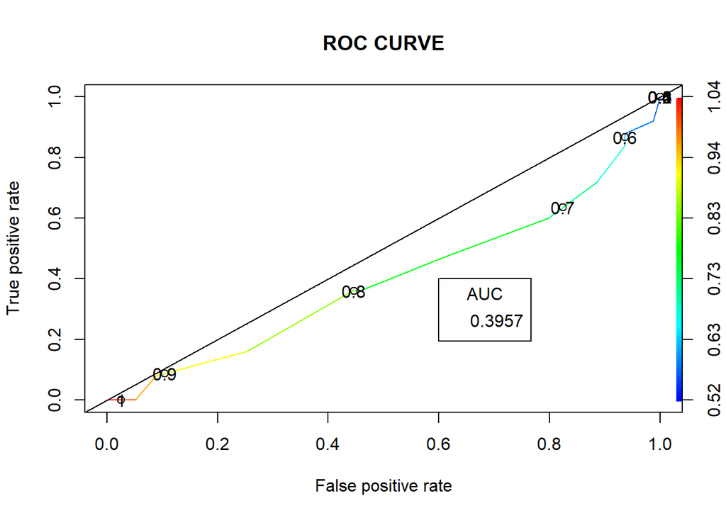

**Results**

**LDA/QDA**

LDA and QDA only include numeric variables from the data set.

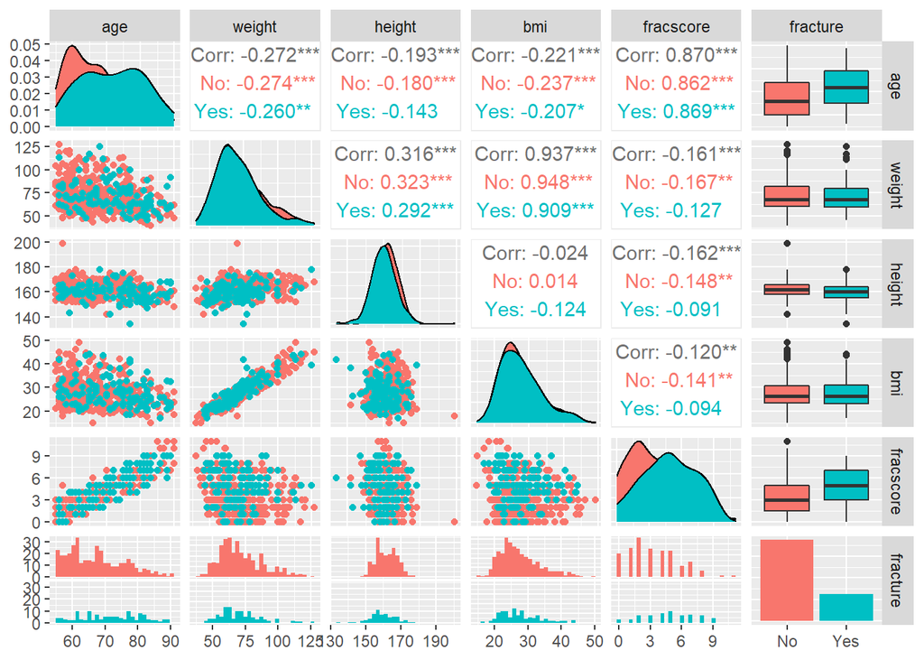

Below is a heat map for numeric varibles.

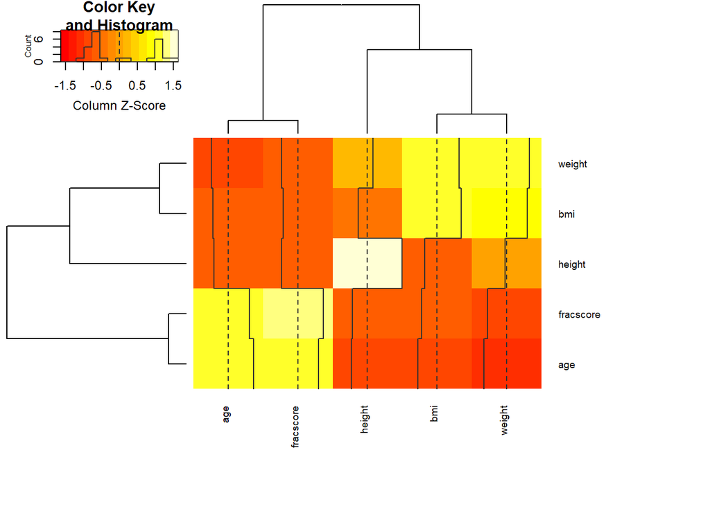

Below are the outliers for all numeric variables.

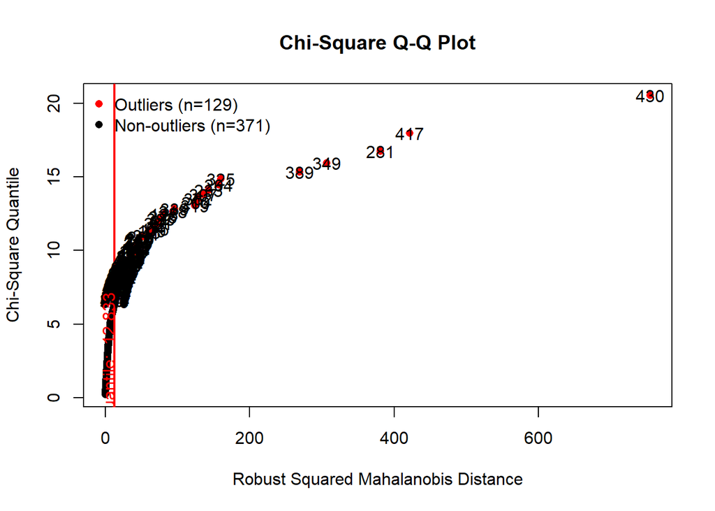

```
## $multivariateNormality
##            Test       HZ p value MVN
## 1 Henze-Zirkler 6.100189       0  NO
##
## $univariateNormality
##               Test  Variable Statistic   p value Normality
## 1 Anderson-Darling    age       6.8419  <0.001      NO
## 2 Anderson-Darling  weight      7.1026  <0.001      NO
## 3 Anderson-Darling  height      1.4860   8e-04      NO
## 4 Anderson-Darling    bmi       7.4465  <0.001      NO
## 5 Anderson-Darling fracscore    6.8334  <0.001      NO
##
## $Descriptives
##             n      Mean   Std.Dev    Median       Min       Max      25th
## age       500  68.56200  8.989537  67.00000  55.00000  90.00000  61.00000
```

[output cut: 142 more lines]

Here are the outliers for just Age, Height, Weight.

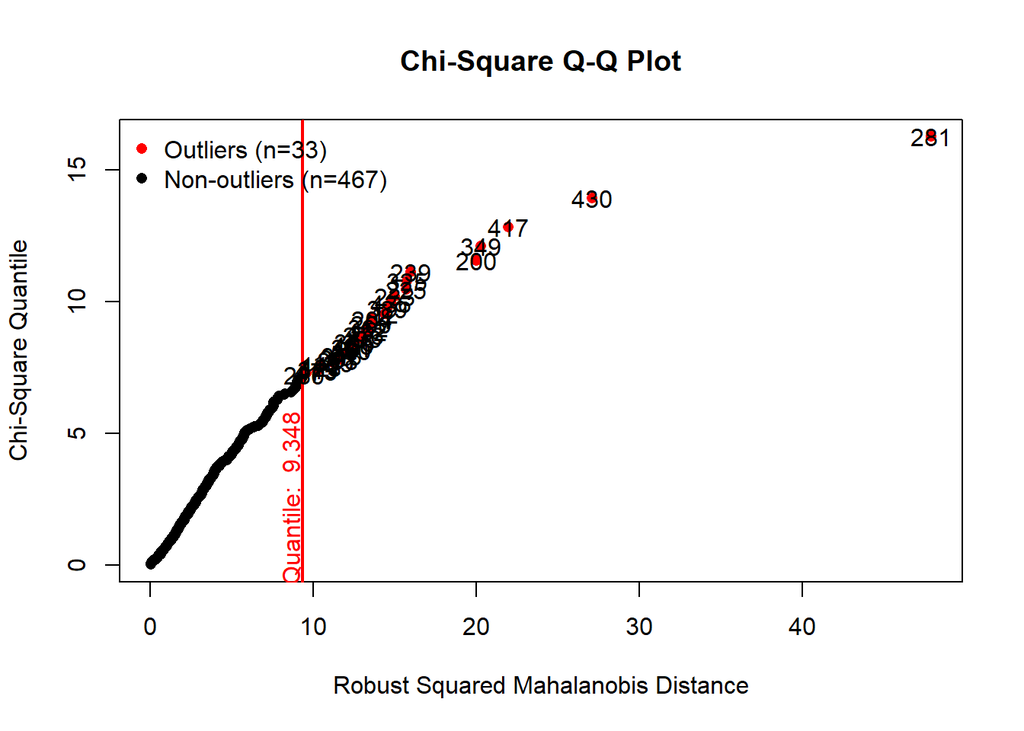

```
## $multivariateNormality
##            Test       HZ p value MVN
## 1 Henze-Zirkler 3.386176       0  NO
##
## $univariateNormality
##               Test  Variable Statistic   p value Normality
## 1 Anderson-Darling    age       6.8419  <0.001      NO
## 2 Anderson-Darling  weight      7.1026  <0.001      NO
## 3 Anderson-Darling  height      1.4860   8e-04      NO
##
## $Descriptives
##          n     Mean   Std.Dev Median   Min Max  25th  75th      Skew   Kurtosis
## age    500  68.5620  8.989537   67.0  55.0  90  61.0  76.0 0.4273768 -0.8356805
## weight 500  71.8232 16.435992   68.0  39.9 127  59.9  81.3 0.8095144  0.3332939
## height 500 161.3640  6.355493  161.5 134.0 199 157.0 165.0 0.2518129  2.4924472
```

[output cut: 36 more lines]

**LDA**

The coefficients of LDA provides the linear combination of variables that are used to form LDA decision rule. The output group means indicates the mean values of different feature when they fall to a particular response class.

```
## Call:
## lda(fracture ~ age + weight + height, data = lq_train)
##
## Prior probabilities of groups:
##        No       Yes
## 0.7512315 0.2487685
##
## Group means:
##          age   weight   height
## No  67.49180 72.56230 161.8328
## Yes 71.70297 70.77228 159.9208
##
## Coefficients of linear discriminants:
##                LD1
## age     0.09716471
## weight  0.01008363
## height -0.07438237
```

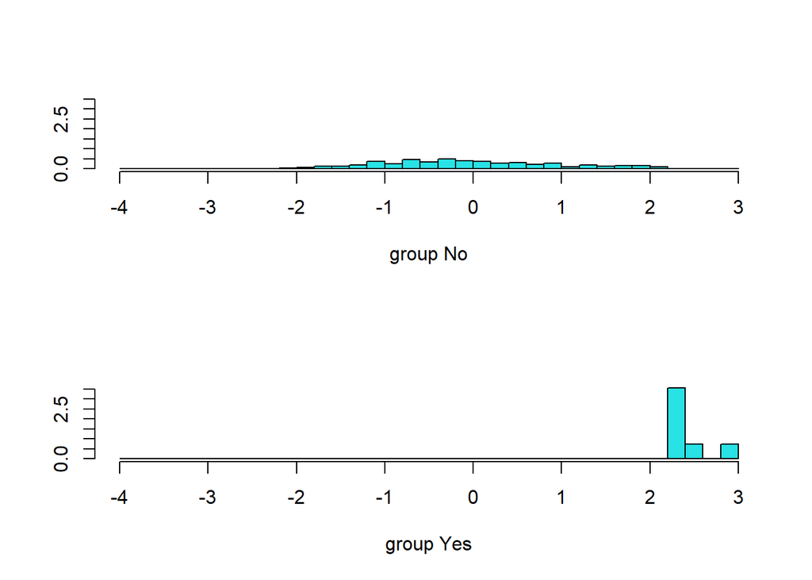

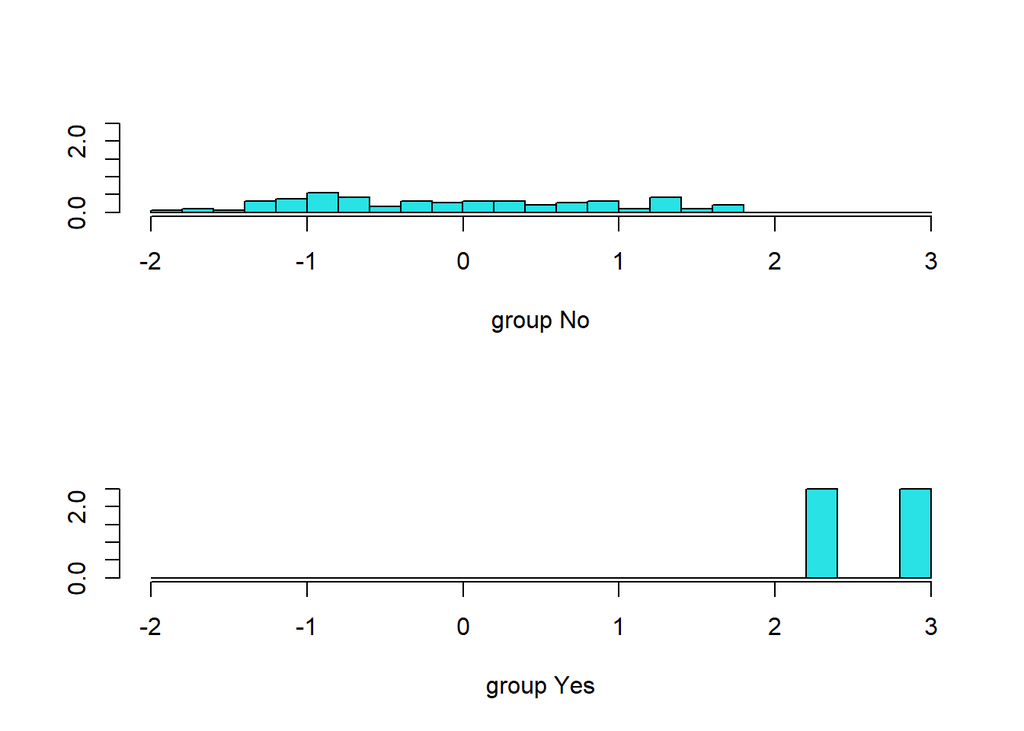

Below are the ROC curve and confusion matrix for LDA.

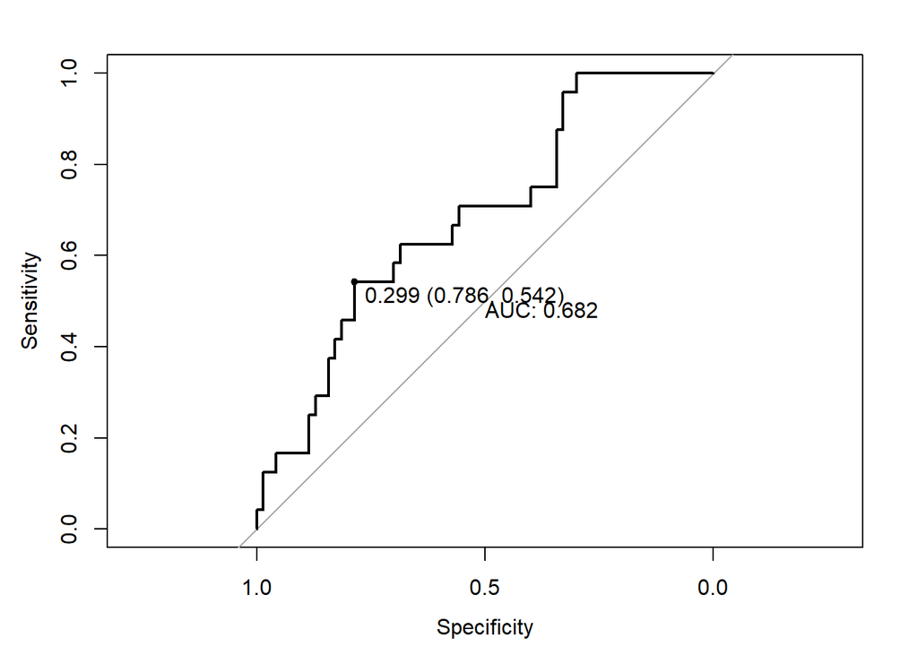

```
## Confusion Matrix and Statistics
##
##           Reference
## Prediction No Yes
##        No  55  11
##        Yes 15  13
##
##                Accuracy : 0.7234
##                  95% CI : (0.6215, 0.8107)
##     No Information Rate : 0.7447
##     P-Value [Acc > NIR] : 0.7270
##
##                   Kappa : 0.3104
##
##  Mcnemar's Test P-Value : 0.5563
##
##             Sensitivity : 0.5417
##             Specificity : 0.7857
##          Pos Pred Value : 0.4643
##          Neg Pred Value : 0.8333
##              Prevalence : 0.2553
##          Detection Rate : 0.1383
##    Detection Prevalence : 0.2979
##       Balanced Accuracy : 0.6637
##
##        'Positive' Class : Yes
##
```

**Results**

Our final model produced the following metrics.

- Sensitivity = .541
- Specificity = .786
- Prevalence = .255
- Positive Predictive Value = .464
- Negative Predictive Value = .833
- Area Under ROC curve = .682

**QDA**

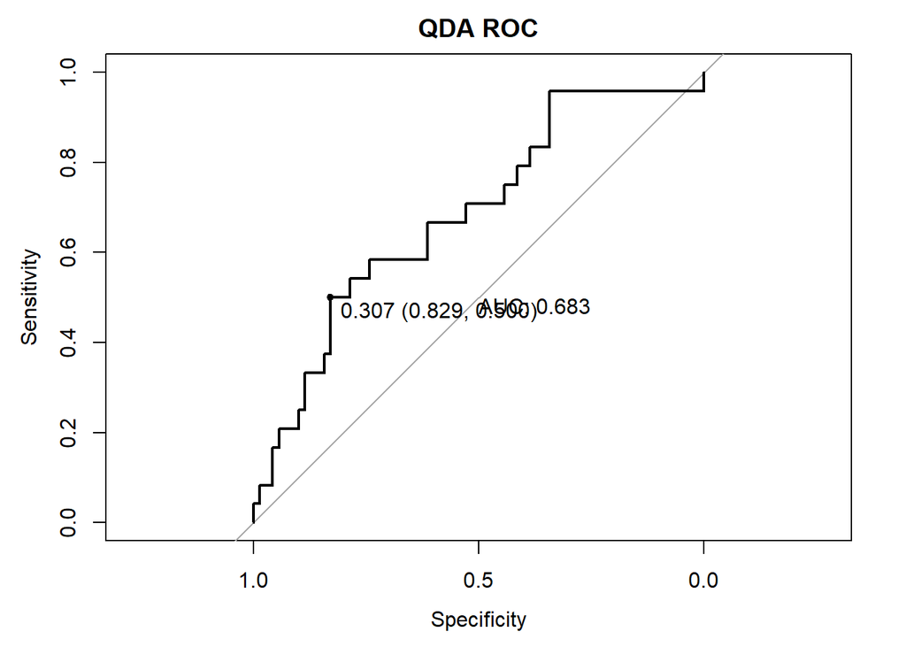

```
## Confusion Matrix and Statistics
##
##           Reference
## Prediction No Yes
##        No  56  12
##        Yes 14  12
##
##                Accuracy : 0.7234
##                  95% CI : (0.6215, 0.8107)
##     No Information Rate : 0.7447
##     P-Value [Acc > NIR] : 0.7270
##
##                   Kappa : 0.292
##
##  Mcnemar's Test P-Value : 0.8445
##
##             Sensitivity : 0.5000
##             Specificity : 0.8000
##          Pos Pred Value : 0.4615
##          Neg Pred Value : 0.8235
##              Prevalence : 0.2553
##          Detection Rate : 0.1277
##    Detection Prevalence : 0.2766
##       Balanced Accuracy : 0.6500
##
##        'Positive' Class : Yes
##
```

**Results**

Our final model produced the following metrics.

- Sensitivity = .500
- Specificity = .800
- Prevalence = .255
- Positive Predictive Value = .462
- Negative Predictive Value = .824
- Area Under ROC curve = .683

LDA vs. QDA logloss evaluation.

```
## Linear Discriminant Analysis
##
## 406 samples
##   3 predictor
##   2 classes: 'No', 'Yes'
##
## No pre-processing
## Resampling: Cross-Validated (5 fold, repeated 1 times)
## Summary of sample sizes: 325, 325, 324, 325, 325
## Resampling results:
##
##   logLoss
##   0.5461359
```

```
## Quadratic Discriminant Analysis
##
## 406 samples
##   3 predictor
##   2 classes: 'No', 'Yes'
##
## No pre-processing
## Resampling: Cross-Validated (5 fold, repeated 1 times)
## Summary of sample sizes: 325, 325, 325, 325, 324
## Resampling results:
##
##   logLoss
##   0.5598495
```

This figure shows how test data has been classified using LDA/QDA model. The mix of red and black colored shows incorrect classification prediction. As you can see in each plot, there are no clear areas that don’t have a mixture of each color.

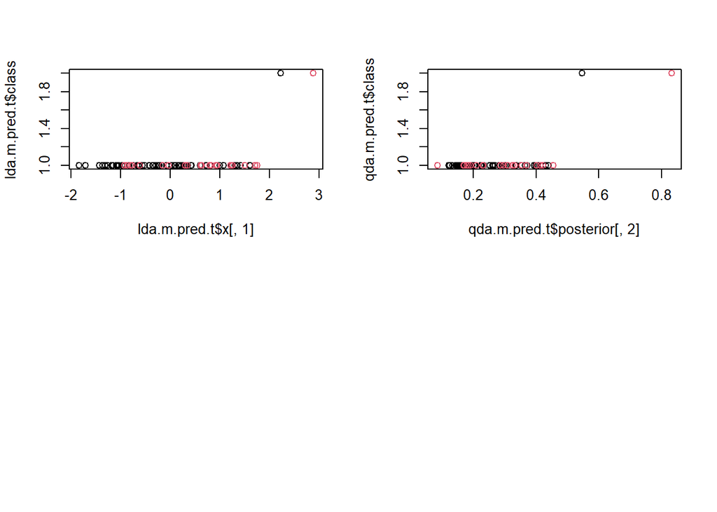

**Additonal Item** Package KlaR help to create exploratory graph for LDA and QDA .

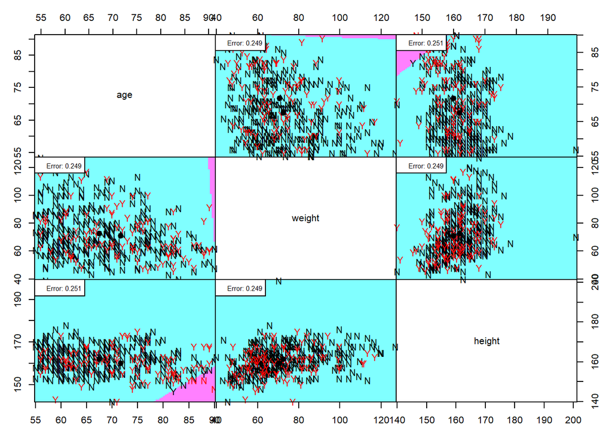

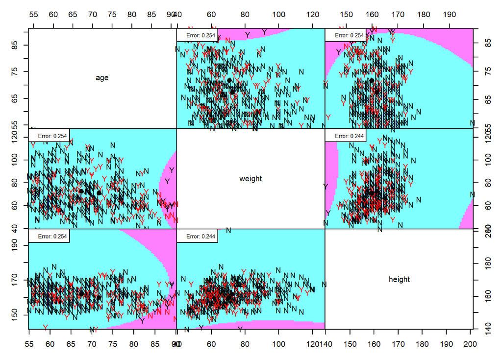

**Complex Logistic Regression**

```r
# Logistic Model
log_model <- glm(fracture ~ priorfrac + momfrac + bonemed_fu + bonetreat + premeno + armassist + raterisk + bonemed + poly(height, degree=3) + poly(weight, degree=3) + poly(fracscore, degree=3) + poly(phy_id, degree=3), data = train_sub, family = "binomial")
coef(summary(log_model))
```

```
##                                Estimate Std. Error     z value     Pr(>|z|)
## (Intercept)                  -1.8709907  0.2963788 -6.31283649 2.739669e-10
## priorfracYes                  0.5790370  0.3097772  1.86920489 6.159431e-02
## momfracYes                    0.5837034  0.3776366  1.54567495 1.221831e-01
## bonemed_fuYes                 1.4195011  0.5809351  2.44347637 1.454652e-02
## bonetreatYes                 -2.0484912  0.9658579 -2.12090323 3.392995e-02
## premenoYes                    0.2002781  0.3354711  0.59700571 5.505036e-01
## armassistYes                 -0.1047933  0.3875477 -0.27040109 7.868517e-01
## rateriskSame                  0.1155311  0.3221498  0.35862556 7.198752e-01
## rateriskGreater               0.3808656  0.3601693  1.05746267 2.903005e-01
## bonemedYes                    1.1007808  0.7664048  1.43629161 1.509194e-01
## poly(height, degree = 3)1    -6.4605346  4.3525380 -1.48431434 1.377255e-01
## poly(height, degree = 3)2    -0.8668256  9.0756759 -0.09551086 9.239091e-01
## poly(height, degree = 3)3    -2.3407469  6.5190882 -0.35906047 7.195499e-01
## poly(weight, degree = 3)1     2.5027454  3.4142570  0.73302782 4.635415e-01
## poly(weight, degree = 3)2    -3.9370301  2.7987647 -1.40670276 1.595155e-01
## poly(weight, degree = 3)3     1.9316490  2.7707160  0.69716600 4.856989e-01
## poly(fracscore, degree = 3)1  8.8548430  4.3134842  2.05282843 4.008922e-02
## poly(fracscore, degree = 3)2 -1.7834591  2.7967532 -0.63768913 5.236761e-01
## poly(fracscore, degree = 3)3 -2.6407892  2.8297898 -0.93321039 3.507114e-01
## poly(phy_id, degree = 3)1     1.9089611  2.7442947  0.69561082 4.866726e-01
## poly(phy_id, degree = 3)2    -2.8776720  2.6782086 -1.07447640 2.826092e-01
## poly(phy_id, degree = 3)3     4.8157745  2.7012633  1.78278603 7.462114e-02
```

```r
summary(glm_both)
```

```
##
## Call:
## glm(formula = fracture ~ priorfrac + momfrac + bonemed_fu + bonetreat +
##     poly(fracscore, degree = 3), family = "binomial", data = train_sub)
##
## Deviance Residuals:
##     Min       1Q   Median       3Q      Max
## -1.7548  -0.7556  -0.4927  -0.4489   2.1656
##
## Coefficients:
##                              Estimate Std. Error z value Pr(>|z|)
## (Intercept)                   -1.6668     0.1833  -9.092  < 2e-16 ***
## priorfracYes                   0.6751     0.2853   2.366  0.01797 *
## momfracYes                     0.6537     0.3471   1.883  0.05968 .
## bonemed_fuYes                  1.5898     0.5567   2.856  0.00429 **
## bonetreatYes                  -1.1383     0.5835  -1.951  0.05108 .
## poly(fracscore, degree = 3)1   8.2841     2.9235   2.834  0.00460 **
## poly(fracscore, degree = 3)2  -2.1693     2.5714  -0.844  0.39889
## poly(fracscore, degree = 3)3  -2.8573     2.5621  -1.115  0.26475
## ---
## Signif. codes:  0 '***' 0.001 '**' 0.01 '*' 0.05 '.' 0.1 ' ' 1
##
## (Dispersion parameter for binomial family taken to be 1)
##
##     Null deviance: 455.51  on 405  degrees of freedom
## Residual deviance: 408.08  on 398  degrees of freedom
## AIC: 424.08
##
## Number of Fisher Scoring iterations: 4
```

AIC

```r
AIC(glm_both)
```

```
## [1] 424.0787
```

BIC

```r
BIC(glm_both)
```

```
## [1] 456.1296
```

Coefficients

```
##                  (Intercept)                 priorfracYes
##                    0.1888411                    1.9642777
##                   momfracYes                bonemed_fuYes
##                    1.9225865                    4.9028853
##                 bonetreatYes poly(fracscore, degree = 3)1
##                    0.3203499                 3960.4533957
## poly(fracscore, degree = 3)2 poly(fracscore, degree = 3)3
##                    0.1142621                    0.0574240
```

Confidence Intervals

```
##                                     2.5 %       97.5 %
## (Intercept)                  1.301507e-01 2.674696e-01
## priorfracYes                 1.120336e+00 3.437350e+00
## momfracYes                   9.618425e-01 3.775101e+00
## bonemed_fuYes                1.667670e+00 1.540217e+01
## bonetreatYes                 9.709068e-02 9.912779e-01
## poly(fracscore, degree = 3)1 1.405620e+01 1.423534e+06
## poly(fracscore, degree = 3)2 6.156737e-04 1.547033e+01
## poly(fracscore, degree = 3)3 3.187165e-04 8.322817e+00
```

Final Model

```r
log_model <- glm(fracture ~ priorfrac + momfrac + bonemed_fu + bonetreat + poly(fracscore, degree=3), data = train_sub, family = "binomial")
summary(log_model)
```

```
##
## Call:
## glm(formula = fracture ~ priorfrac + momfrac + bonemed_fu + bonetreat +
##     poly(fracscore, degree = 3), family = "binomial", data = train_sub)
##
## Deviance Residuals:
##     Min       1Q   Median       3Q      Max
## -1.7548  -0.7556  -0.4927  -0.4489   2.1656
##
## Coefficients:
##                              Estimate Std. Error z value Pr(>|z|)
## (Intercept)                   -1.6668     0.1833  -9.092  < 2e-16 ***
## priorfracYes                   0.6751     0.2853   2.366  0.01797 *
## momfracYes                     0.6537     0.3471   1.883  0.05968 .
## bonemed_fuYes                  1.5898     0.5567   2.856  0.00429 **
## bonetreatYes                  -1.1383     0.5835  -1.951  0.05108 .
## poly(fracscore, degree = 3)1   8.2841     2.9235   2.834  0.00460 **
## poly(fracscore, degree = 3)2  -2.1693     2.5714  -0.844  0.39889
## poly(fracscore, degree = 3)3  -2.8573     2.5621  -1.115  0.26475
## ---
## Signif. codes:  0 '***' 0.001 '**' 0.01 '*' 0.05 '.' 0.1 ' ' 1
##
## (Dispersion parameter for binomial family taken to be 1)
##
##     Null deviance: 455.51  on 405  degrees of freedom
## Residual deviance: 408.08  on 398  degrees of freedom
## AIC: 424.08
##
## Number of Fisher Scoring iterations: 4
```

```r
# Model Performance
confusionMatrix(data = as.factor(predict_test_fact), reference = test$fracture)
```

```
## Confusion Matrix and Statistics
##
##           Reference
## Prediction No Yes
##        No  50   9
##        Yes 20  15
##
##                Accuracy : 0.6915
##                  95% CI : (0.5878, 0.7827)
##     No Information Rate : 0.7447
##     P-Value [Acc > NIR] : 0.90143
##
##                   Kappa : 0.2949
##
##  Mcnemar's Test P-Value : 0.06332
##
##             Sensitivity : 0.7143
##             Specificity : 0.6250
##          Pos Pred Value : 0.8475
##          Neg Pred Value : 0.4286
##              Prevalence : 0.7447
##          Detection Rate : 0.5319
##    Detection Prevalence : 0.6277
##       Balanced Accuracy : 0.6696
##
##        'Positive' Class : No
##
```

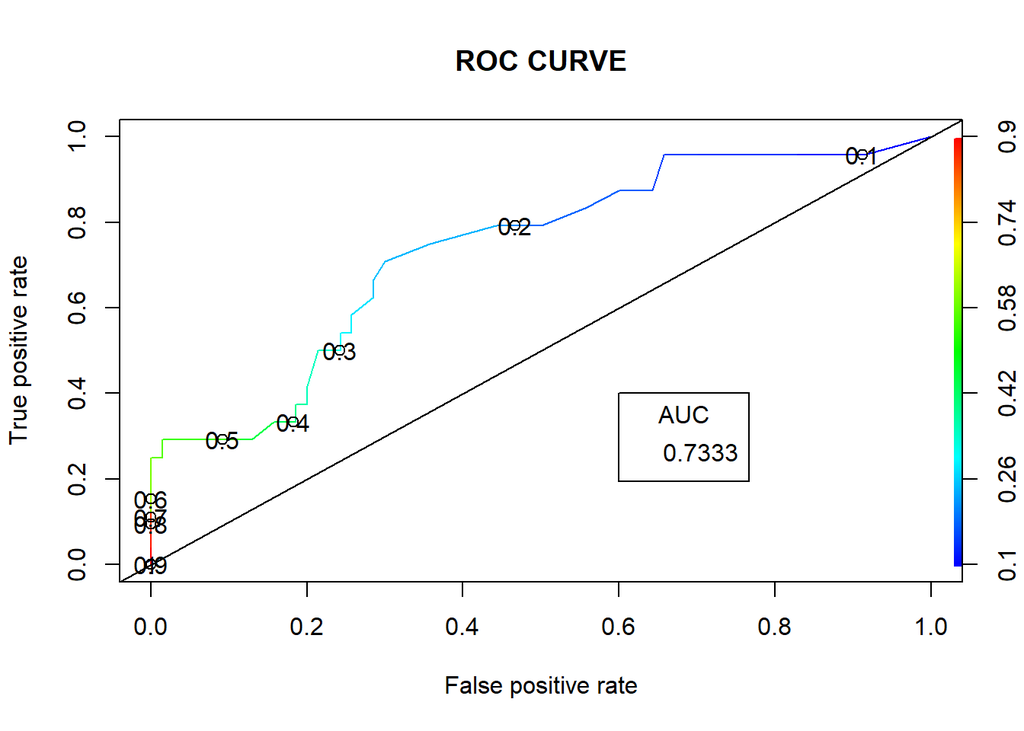

# **Results**

Our final model produced the following metrics.

- Sensitivity = .714
- Specificity = .625
- Prevalence = .745
- Positive Predictive Value = .848
- Negative Predictive Value = .429
- Area Under ROC curve = .733

The net result when adding polynomial terms was a negligible change in metrics for an increased complixity of model. The suggested model is still the simple logistic model from Objective 1.

Overlap ROC curve

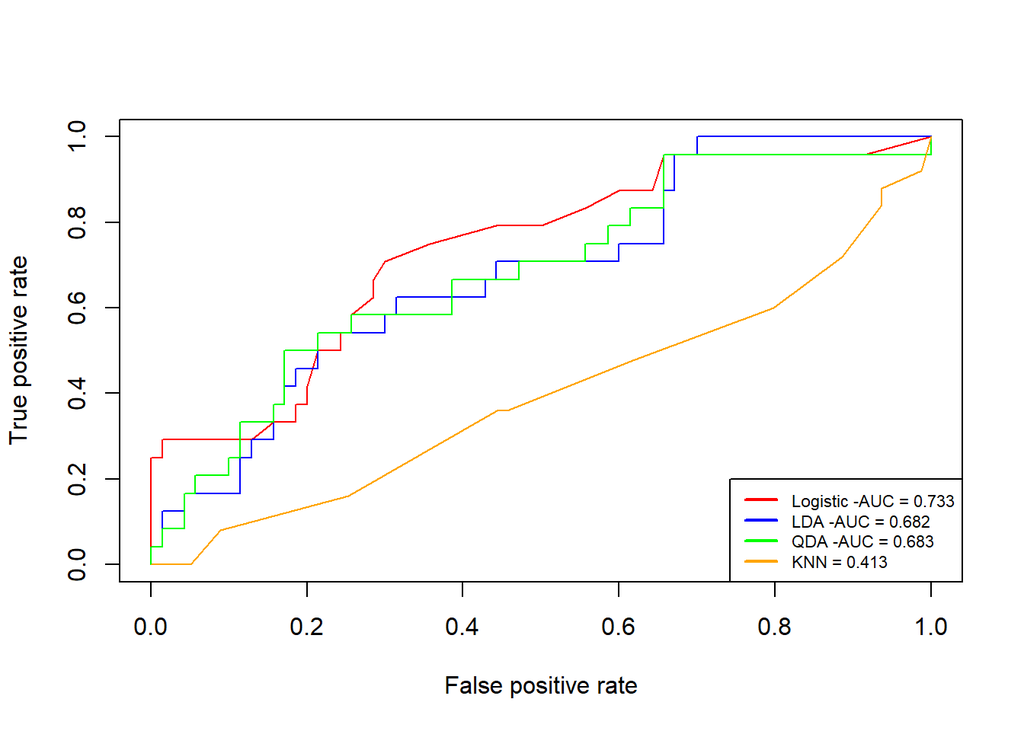

[output not shown]